# Citi Bike NYC System Dataset

**by Eric Law Yuwei**

## Introduction

Citi Bike is New York City’s bike share system, and the largest in the nation. Citi Bike launched in May 2013 and has become an essential part of our transportation network. It's fun, efficient and affordable – not to mention healthy and good for the environment.

Citi Bike consists of a fleet of specially designed, sturdy and durable bikes that are locked into a network of docking stations throughout the city. The bikes can be unlocked from one station and returned to any other station in the system, making them ideal for one-way trips. People use bike share to commute to work or school, run errands, get to appointments or social engagements, and more. Citi Bike is available anytime, anyday, and riders have access to thousands of bikes at hundreds of stations across Manhattan, Brooklyn, Queens and Jersey City.

In this project, I will be investigating the **year 2020** Citi Bike dataset and how Covid19 pandemic affect the trend of Citi Bike movement.

**Note**:The dataset can be obtain from here: https://www.citibikenyc.com/system-data which include

Trip Duration (seconds)  
Start Time and Date  
Stop Time and Date  
Start Station Name  
End Station Name  
Station ID  
Station Lat/Long  
Bike ID  
User Type (Customer = 24-hour pass or 3-day pass user; Subscriber = Annual Member)  
Gender (Zero=unknown; 1=male; 2=female)  
Year of Birth

# Preliminary Wrangling

```python
# import required libraries
import numpy as np
import pandas as pd
import matplotlib.pyplot as plt
import seaborn as sns
sns.set_style('darkgrid')
from requests import get
from zipfile import ZipFile
from io import StringIO, BytesIO
%matplotlib inline

sns.set_style('darkgrid')

plt.rcParams['font.family'] = "sans-serif"
color_palette_list = ['#009ACD', '#ADD8E6', '#63D1F4', '#0EBFE9',
                      '#C1F0F6', '#0099CC']
```

Load in your dataset and describe its properties through the questions below. Try and motivate your exploration goals through this section.

```python
#download and unzip citi bike dataset
url = ["https://s3.amazonaws.com/tripdata/JC-202001-citibike-tripdata.csv.zip","https://s3.amazonaws.com/tripdata/JC-202002-citibike-tripdata.csv.zip"
        ,"https://s3.amazonaws.com/tripdata/JC-202003-citibike-tripdata.csv.zip","https://s3.amazonaws.com/tripdata/JC-202004-citibike-tripdata.csv.zip"
        ,"https://s3.amazonaws.com/tripdata/JC-202005-citibike-tripdata.csv.zip","https://s3.amazonaws.com/tripdata/JC-202006-citibike-tripdata.csv.zip"
        ,"https://s3.amazonaws.com/tripdata/JC-202007-citibike-tripdata.csv.zip","https://s3.amazonaws.com/tripdata/JC-202008-citibike-tripdata.csv.zip"
        ,"https://s3.amazonaws.com/tripdata/JC-202009-citibike-tripdata.csv.zip","https://s3.amazonaws.com/tripdata/JC-202010-citibike-tripdata.csv.zip"
        ,"https://s3.amazonaws.com/tripdata/JC-202011-citibike-tripdata.csv.zip","https://s3.amazonaws.com/tripdata/JC-202012-citibike-tripdata.csv.zip"]


for link in url:
    zipfile = get(link)
    with ZipFile(BytesIO(zipfile.content)) as file:
        file.extractall()
```

```python
# merge all dataset into one
paths = ['JC-202001-citibike-tripdata.csv','JC-202002-citibike-tripdata.csv'
       ,'JC-202003-citibike-tripdata.csv','JC-202004-citibike-tripdata.csv'
       ,'JC-202005-citibike-tripdata.csv','JC-202006-citibike-tripdata.csv'
       ,'JC-202007-citibike-tripdata.csv','JC-202008-citibike-tripdata.csv'
       ,'JC-202009-citibike-tripdata.csv','JC-202010-citibike-tripdata.csv'
       ,'JC-202011-citibike-tripdata.csv','JC-202012-citibike-tripdata.csv']
df = pd.read_csv('JC-202001-citibike-tripdata.csv')
for path in paths:
    df = df.append(pd.read_csv(path))
```

```python
# it seems like all columns has no null value, that's great 1
df.info()
```

```
<class 'pandas.core.frame.DataFrame'>
Int64Index: 362822 entries, 0 to 11693
Data columns (total 15 columns):
 #   Column                   Non-Null Count   Dtype
---  ------                   --------------   -----
 0   tripduration             362822 non-null  int64
 1   starttime                362822 non-null  object
 2   stoptime                 362822 non-null  object
 3   start station id         362822 non-null  int64
 4   start station name       362822 non-null  object
 5   start station latitude   362822 non-null  float64
 6   start station longitude  362822 non-null  float64
 7   end station id           362822 non-null  int64
 8   end station name         362822 non-null  object
 9   end station latitude     362822 non-null  float64
 10  end station longitude    362822 non-null  float64
 11  bikeid                   362822 non-null  int64
 12  usertype                 362822 non-null  object
 13  birth year               362822 non-null  int64
 14  gender                   362822 non-null  int64
dtypes: float64(4), int64(6), object(5)
memory usage: 44.3+ MB
```

```python
# make a copy and drop unnecessary columns
df1=df.copy()
df1=df1.drop(['start station id','end station id','bikeid'],axis=1)
df1.head(3)
```

|  | tripduration | starttime | stoptime | start station name | start station latitude | start station longitude | end station name | end station latitude | end station longitude | usertype | birth year | gender |
| --- | --- | --- | --- | --- | --- | --- | --- | --- | --- | --- | --- | --- |
| 0 | 226 | 2020-01-01 00:04:50.1920 | 2020-01-01 00:08:37.0370 | Grove St PATH | 40.719586 | -74.043117 | Newark Ave | 40.721525 | -74.046305 | Subscriber | 1984 | 2 |
| 1 | 377 | 2020-01-01 00:16:01.6700 | 2020-01-01 00:22:19.0800 | Grove St PATH | 40.719586 | -74.043117 | Brunswick & 6th | 40.726012 | -74.050389 | Subscriber | 1989 | 2 |
| 2 | 288 | 2020-01-01 00:17:33.8770 | 2020-01-01 00:22:22.4420 | Grove St PATH | 40.719586 | -74.043117 | Brunswick & 6th | 40.726012 | -74.050389 | Customer | 1989 | 1 |

```python
# Changing the format to datetime
df1['starttime'] = pd.to_datetime(df1['starttime'])
df1['stoptime'] = pd.to_datetime(df1['stoptime'])
# Changing the usertype and gender to category format
df1['usertype'] = df1['usertype'].astype('category')
df1['gender'] = df1['gender'].astype('category')
```

```python
#extract date, week , month , year from start time.
df1['start_hour'] = df1.starttime.dt.hour
df1['start_date'] = df1.starttime.dt.strftime('%Y-%m-%d')
df1['start_day_week'] = df1.starttime.dt.strftime('%A')
df1['start_month'] =  df1.starttime.dt.strftime('%B')
df1['year'] = df1.starttime.dt.strftime('%Y')
#computing duration in minute
df1['tripduration_min'] = df1['tripduration']/60
del df1['tripduration']
#computing age
df1['Age'] = 2021 - df1['birth year']
```

```python
#replacing numerical value to categorical variable
df1['gender']=df1['gender'].replace({0:'Unknown', 1: 'Male', 2:'Female'})
```

```python
# Formula to calculate distance in KM
# https://stackoverflow.com/questions/19412462/getting-distance-between-two-points-based-on-latitude-longitude
from math import sin, cos, sqrt, atan2, radians

def distance (lat1,lon1,lat2,lon2):
    R = 6373.0 # Earth Radius in KM

    lat1 = radians(lat1)
    lon1 = radians(lon1)
    lat2 = radians(lat2)
    lon2 = radians(lon2)

    dlon = lon2 - lon1
    dlat = lat2 - lat1

    a = sin(dlat / 2)**2 + cos(lat1) * cos(lat2) * sin(dlon / 2)**2
    c = 2 * atan2(sqrt(a), sqrt(1 - a))

    distance = R * c
    return np.float64((distance))
```

```python
df1['distance'] = df1.apply(lambda z: distance(z['start station latitude'],z['start station longitude'],z['end station latitude'],z['end station longitude']),axis=1)
```

```python
# Statistical Analysis
df1.describe()
```

[output not shown]

According the statistical summary, there are several outlier in some features. Age , tripduration_min and distance contain unrealistic data. Lets do further investigation on it.

```python
## Filter the outlier
#filter out tripduration_min > 300 as it is equivalent to 5 hours which is not very common.
df1=df1.query('tripduration_min < 40')
#filter out age > 70
df1= df1.query('Age <70')
#filter out distance > 20km
df1=df1.query('distance <3')
df1
```

|  | starttime | stoptime | start station name | start station latitude | start station longitude | end station name | end station latitude | end station longitude | usertype | birth year | gender | start_hour | start_date | start_day_week | start_month | year | tripduration_min | Age | distance |
| --- | --- | --- | --- | --- | --- | --- | --- | --- | --- | --- | --- | --- | --- | --- | --- | --- | --- | --- | --- |
| 0 | 2020-01-01 00:04:50.192 | 2020-01-01 00:08:37.037 | Grove St PATH | 40.719586 | -74.043117 | Newark Ave | 40.721525 | -74.046305 | Subscriber | 1984 | Female | 0 | 2020-01-01 | Wednesday | January | 2020 | 3.766667 | 37 | 0.344533 |
| 1 | 2020-01-01 00:16:01.670 | 2020-01-01 00:22:19.080 | Grove St PATH | 40.719586 | -74.043117 | Brunswick & 6th | 40.726012 | -74.050389 | Subscriber | 1989 | Female | 0 | 2020-01-01 | Wednesday | January | 2020 | 6.283333 | 32 | 0.941573 |
| 2 | 2020-01-01 00:17:33.877 | 2020-01-01 00:22:22.442 | Grove St PATH | 40.719586 | -74.043117 | Brunswick & 6th | 40.726012 | -74.050389 | Customer | 1989 | Male | 0 | 2020-01-01 | Wednesday | January | 2020 | 4.800000 | 32 | 0.941573 |
| 3 | 2020-01-01 00:32:05.902 | 2020-01-01 00:39:21.066 | Sip Ave | 40.730897 | -74.063913 | Astor Place | 40.719282 | -74.071262 | Customer | 1969 | Unknown | 0 | 2020-01-01 | Wednesday | January | 2020 | 7.250000 | 52 | 1.432779 |
| 4 | 2020-01-01 00:46:19.678 | 2020-01-01 00:50:11.344 | Grove St PATH | 40.719586 | -74.043117 | Marin Light Rail | 40.714584 | -74.042817 | Subscriber | 1983 | Female | 0 | 2020-01-01 | Wednesday | January | 2020 | 3.850000 | 38 | 0.556957 |
| ... | ... | ... | ... | ... | ... | ... | ... | ... | ... | ... | ... | ... | ... | ... | ... | ... | ... | ... | ... |
| 11687 | 2020-12-31 22:38:25.468 | 2020-12-31 22:49:18.515 | Grand St | 40.715178 | -74.037683 | Grand St | 40.715178 | -74.037683 | Subscriber | 1980 | Male | 22 | 2020-12-31 | Thursday | December | 2020 | 10.883333 | 41 | 0.000000 |
| 11689 | 2020-12-31 23:07:44.003 | 2020-12-31 23:36:54.471 | Newport Pkwy | 40.728745 | -74.032108 | Newport Pkwy | 40.728745 | -74.032108 | Customer | 1969 | Unknown | 23 | 2020-12-31 | Thursday | December | 2020 | 29.166667 | 52 | 0.000000 |
| 11691 | 2020-12-31 23:31:09.462 | 2021-01-01 00:00:31.329 | Sip Ave | 40.730897 | -74.063913 | Jersey & 6th St | 40.725289 | -74.045572 | Customer | 1998 | Male | 23 | 2020-12-31 | Thursday | December | 2020 | 29.350000 | 23 | 1.667085 |
| 11692 | 2020-12-31 23:35:45.464 | 2020-12-31 23:46:22.730 | Grand St | 40.715178 | -74.037683 | Newport Pkwy | 40.728745 | -74.032108 | Customer | 1969 | Unknown | 23 | 2020-12-31 | Thursday | December | 2020 | 10.616667 | 52 | 1.580559 |
| 11693 | 2020-12-31 23:48:34.575 | 2021-01-01 00:15:22.309 | Morris Canal | 40.712419 | -74.038526 | Morris Canal | 40.712419 | -74.038526 | Subscriber | 1982 | Male | 23 | 2020-12-31 | Thursday | December | 2020 | 26.783333 | 39 | 0.000000 |

276137 rows × 19 columns

```python
#Check any duplicates
df1.duplicated().sum()
```

[output not shown]

```python
# Remove duplicates
df1=df1.drop_duplicates()
df1.duplicated().sum()
```

```
0
```

```python
df1.info()
```

```
<class 'pandas.core.frame.DataFrame'>
Int64Index: 276137 entries, 0 to 11693
Data columns (total 19 columns):
 #   Column                   Non-Null Count   Dtype
---  ------                   --------------   -----
 0   starttime                276137 non-null  datetime64[ns]
 1   stoptime                 276137 non-null  datetime64[ns]
 2   start station name       276137 non-null  object
 3   start station latitude   276137 non-null  float64
 4   start station longitude  276137 non-null  float64
 5   end station name         276137 non-null  object
 6   end station latitude     276137 non-null  float64
 7   end station longitude    276137 non-null  float64
 8   usertype                 276137 non-null  category
 9   birth year               276137 non-null  int64
 10  gender                   276137 non-null  object
 11  start_hour               276137 non-null  int64
 12  start_date               276137 non-null  object
 13  start_day_week           276137 non-null  object
 14  start_month              276137 non-null  object
 15  year                     276137 non-null  object
 16  tripduration_min         276137 non-null  float64
 17  Age                      276137 non-null  int64
 18  distance                 276137 non-null  float64
dtypes: category(1), datetime64[ns](2), float64(6), int64(3), object(7)
memory usage: 40.3+ MB
```

```python
#shape of the dataframe before clean
print('df:',df.shape)
#shape of the dataframe after clean
print('df1:',df1.shape)
```

```
df: (362822, 15)
df1: (276137, 19)
```

```python
df1_clean=df1
```

```python
df1_clean.to_csv('df1_clean',index=False)
df1_clean
```

|  | starttime | stoptime | start station name | start station latitude | start station longitude | end station name | end station latitude | end station longitude | usertype | birth year | gender | start_hour | start_date | start_day_week | start_month | year | tripduration_min | Age | distance |
| --- | --- | --- | --- | --- | --- | --- | --- | --- | --- | --- | --- | --- | --- | --- | --- | --- | --- | --- | --- |
| 0 | 2020-01-01 00:04:50.192 | 2020-01-01 00:08:37.037 | Grove St PATH | 40.719586 | -74.043117 | Newark Ave | 40.721525 | -74.046305 | Subscriber | 1984 | Female | 0 | 2020-01-01 | Wednesday | January | 2020 | 3.766667 | 37 | 0.344533 |
| 1 | 2020-01-01 00:16:01.670 | 2020-01-01 00:22:19.080 | Grove St PATH | 40.719586 | -74.043117 | Brunswick & 6th | 40.726012 | -74.050389 | Subscriber | 1989 | Female | 0 | 2020-01-01 | Wednesday | January | 2020 | 6.283333 | 32 | 0.941573 |
| 2 | 2020-01-01 00:17:33.877 | 2020-01-01 00:22:22.442 | Grove St PATH | 40.719586 | -74.043117 | Brunswick & 6th | 40.726012 | -74.050389 | Customer | 1989 | Male | 0 | 2020-01-01 | Wednesday | January | 2020 | 4.800000 | 32 | 0.941573 |
| 3 | 2020-01-01 00:32:05.902 | 2020-01-01 00:39:21.066 | Sip Ave | 40.730897 | -74.063913 | Astor Place | 40.719282 | -74.071262 | Customer | 1969 | Unknown | 0 | 2020-01-01 | Wednesday | January | 2020 | 7.250000 | 52 | 1.432779 |
| 4 | 2020-01-01 00:46:19.678 | 2020-01-01 00:50:11.344 | Grove St PATH | 40.719586 | -74.043117 | Marin Light Rail | 40.714584 | -74.042817 | Subscriber | 1983 | Female | 0 | 2020-01-01 | Wednesday | January | 2020 | 3.850000 | 38 | 0.556957 |
| ... | ... | ... | ... | ... | ... | ... | ... | ... | ... | ... | ... | ... | ... | ... | ... | ... | ... | ... | ... |
| 11687 | 2020-12-31 22:38:25.468 | 2020-12-31 22:49:18.515 | Grand St | 40.715178 | -74.037683 | Grand St | 40.715178 | -74.037683 | Subscriber | 1980 | Male | 22 | 2020-12-31 | Thursday | December | 2020 | 10.883333 | 41 | 0.000000 |
| 11689 | 2020-12-31 23:07:44.003 | 2020-12-31 23:36:54.471 | Newport Pkwy | 40.728745 | -74.032108 | Newport Pkwy | 40.728745 | -74.032108 | Customer | 1969 | Unknown | 23 | 2020-12-31 | Thursday | December | 2020 | 29.166667 | 52 | 0.000000 |
| 11691 | 2020-12-31 23:31:09.462 | 2021-01-01 00:00:31.329 | Sip Ave | 40.730897 | -74.063913 | Jersey & 6th St | 40.725289 | -74.045572 | Customer | 1998 | Male | 23 | 2020-12-31 | Thursday | December | 2020 | 29.350000 | 23 | 1.667085 |
| 11692 | 2020-12-31 23:35:45.464 | 2020-12-31 23:46:22.730 | Grand St | 40.715178 | -74.037683 | Newport Pkwy | 40.728745 | -74.032108 | Customer | 1969 | Unknown | 23 | 2020-12-31 | Thursday | December | 2020 | 10.616667 | 52 | 1.580559 |
| 11693 | 2020-12-31 23:48:34.575 | 2021-01-01 00:15:22.309 | Morris Canal | 40.712419 | -74.038526 | Morris Canal | 40.712419 | -74.038526 | Subscriber | 1982 | Male | 23 | 2020-12-31 | Thursday | December | 2020 | 26.783333 | 39 | 0.000000 |

276137 rows × 19 columns

### What is the structure of your dataset?

> The initial dataset has 362822 rows of data with over 15 features. After cleaning, there are 276137 rows of data with total 19 features.

### What is/are the main feature(s) of interest in your dataset?

> I'm interested to investigate the rides trend vary per age, gender, weekday, hour of a day and month.

### What features in the dataset do you think will help support your investigation into your feature(s) of interest?

- start date (YYYY-MM-DD)
- start date week
- start month
- year
- duration min
- age
- Distance in KM

## Univariate Exploration

> In this section, investigate distributions of individual variables. If you see unusual points or outliers, take a deeper look to clean things up and prepare yourself to look at relationships between variables.

**Checking the Citi Bike users Age**

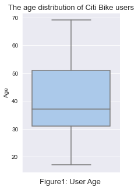

```python
plt.figure(figsize=(3,5))
sns.boxplot(y='Age', data=df1_clean, orient='v',palette='pastel')
plt.title("The age distribution of Citi Bike users", fontsize=13)
plt.xlabel("Figure1: User Age ", fontsize=13)
```

After cleaning, it looks like user age are well distributed.

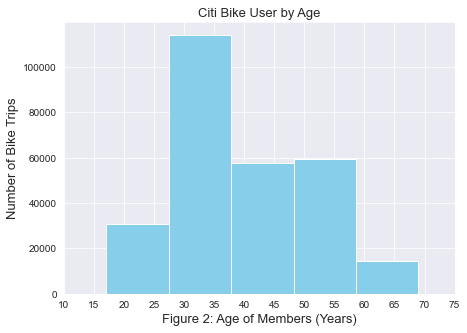

```python
plt.rcParams['font.family'] = "sans-serif"
plt.figure(figsize=(7,5))
plt.hist(data = df1_clean, x = 'Age', bins = 5,color="skyBlue");
plt.xticks(range(10,80,5))
plt.title("Citi Bike User by Age",fontsize=13)
plt.xlabel('Figure 2: Age of Members (Years)',fontsize=13)
plt.ylabel('Number of Bike Trips',fontsize=13);
```

**Checking the Citi Bike users Gender**

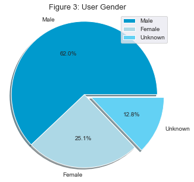

```python
gender_ = df1_clean['gender'].value_counts()
plt.rcParams['font.family'] = "sans-serif"
color_palette_list = ['#009ACD', '#ADD8E6', '#63D1F4']
plt.rcParams["legend.loc"] = 'best'
plt.figure(figsize=(5,5))
label = ['Male','Female','Unknown']
plt.pie(gender_,labels=label,radius=1,autopct='%0.1f%%',shadow=True,explode=[0,0,0.1],colors=color_palette_list)
plt.axis('equal')
plt.title('Figure 3: User Gender',fontsize=13)
plt.legend()
plt.show()
```

The piechart shows that the majority of bike user are Male

**Checking the Citi Bike users by 7-day-week**

```python
df1_clean['start_day_week'].value_counts()
```

```
Saturday     43892
Wednesday    39998
Tuesday      39497
Sunday       39339
Thursday     38829
Friday       38505
Monday       36077
Name: start_day_week, dtype: int64
```

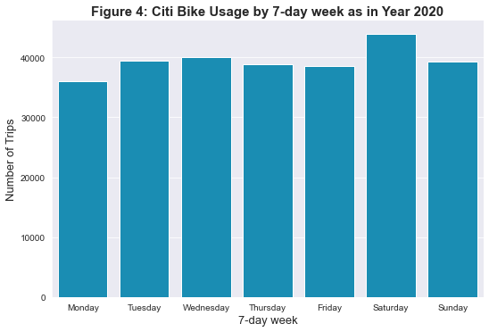

```python
plt.rcParams['font.family'] = "sans-serif"
label = ['Monday', 'Tuesday', 'Wednesday', 'Thursday', 'Friday', 'Saturday', 'Sunday']
sns.catplot(data=df1_clean, x='start_day_week', kind='count',palette=['#009ACD'], order = label, aspect = 1.5)
plt.xlabel('7-day week',fontsize=13)
plt.ylabel('Number of Trips',fontsize=13)
plt.title('Figure 4: Citi Bike Usage by 7-day week as in Year 2020', fontsize=15, fontweight='bold');
```

Saturday is the most popular day for bike usage, however most of the day are well distributed with slight difference.

**Checking the Citi Bike usage by hour**

```python
df1_clean['start_hour'].value_counts()
```

```
18    28064
17    26526
19    22133
16    20465
15    17904
14    16331
13    15969
8     15919
12    15539
20    14640
11    13031
9     12531
7     11828
10    11265
21     9033
22     6719
6      6231
23     4183
0      2590
5      2039
1      1379
2       691
4       687
3       440
Name: start_hour, dtype: int64
```

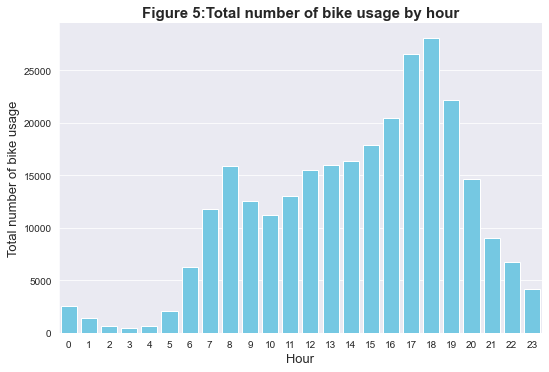

```python
plt.rcParams['font.family'] = "sans-serif"
plt.figure(figsize=(8,7))
sns.catplot(data = df1_clean, x='start_hour' ,kind='count',palette=['#63D1F4'],aspect= 1.5);
plt.title("Figure 5:Total number of bike usage by hour",fontsize=15, fontweight='bold')
plt.xlabel("Hour",fontsize=13)
plt.ylabel("Total number of bike usage",fontsize=13)
```

Based on the diagram, the peak hour for bike usage is between 5-6pm evening.

**Checking the Citi Bike usage by month**

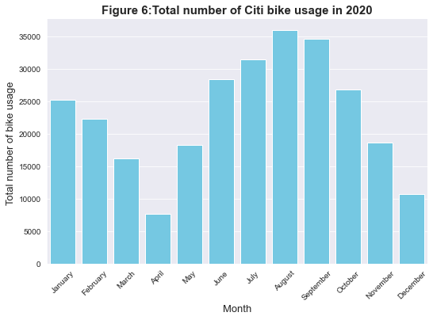

```python
plt.rcParams['font.family'] = "sans-serif"
plt.figure(figsize=(8,7))
sns.catplot(data = df1_clean, x='start_month' ,kind='count',palette=['#63D1F4'],aspect= 1.5);
plt.title("Figure 6:Total number of Citi bike usage in 2020",fontsize=15, fontweight='bold')
plt.xlabel("Month",fontsize=13)
plt.ylabel("Total number of bike usage ",fontsize=13)
plt.xticks(rotation=45)
```

April has the lowest bike usage in New York. According to BBC news, government response to the Covid 19 pandemic in New York began with a full lockdown from March 2020 to April 2020, followed by a four-phase reopening plan by region from April 2020 to July 2020.

**Checking the most & least popular place to rent Citi Bike.**

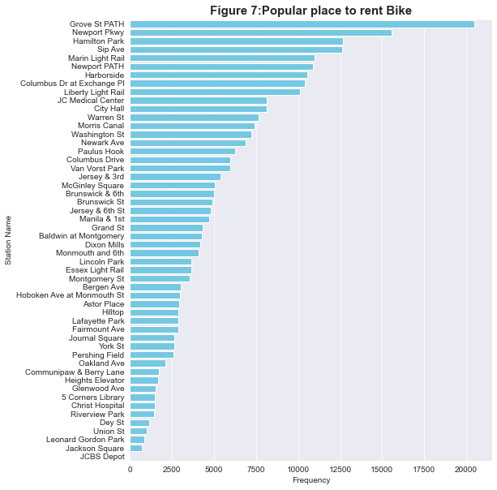

```python
plt.rcParams['font.family'] = "sans-serif"
orders = df1_clean['start station name'].value_counts().index
plt.figure(figsize=(8,10))
sns.countplot(y = df1_clean['start station name'],order=orders,palette=['#63D1F4'])
plt.title("Figure 7:Popular place to rent Bike",fontweight='bold',fontsize=15)
plt.xlabel("Frequency")
plt.ylabel("Station Name")
```

**Checking the trip duration in minute**

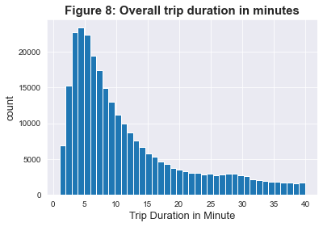

```python
plt.rcParams['font.family'] = "sans-serif"
plt.hist(data=df1_clean, x='tripduration_min', bins=40);
ticks = np.arange(0, 45, 5)
plt.xticks(ticks, ticks);
plt.title("Figure 8: Overall trip duration in minutes",fontsize=15,fontweight='bold')
plt.xlabel('Trip Duration in Minute',fontsize=13);
plt.ylabel('count',fontsize=13)
```

It looks like most of the trip duration fall between 4-7 minutes. This sugests most user are renting the bike for short distances.

**Checking Citi bike type of user**

```python
usertype_=df1_clean['usertype'].value_counts()
usertype_
```

```
Subscriber    204665
Customer       71472
Name: usertype, dtype: int64
```

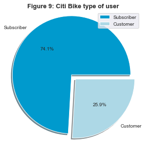

```python
plt.rcParams['font.family'] = "sans-serif"
color_palette_list = ['#009ACD', '#ADD8E6', '#63D1F4']
plt.rcParams["legend.loc"] = 'best'
plt.figure(figsize=(5,5))
label = ['Subscriber','Customer']
plt.pie(usertype_,labels=label,radius=1,autopct='%0.1f%%',shadow=True,explode=[0,0.1],colors=color_palette_list)
plt.axis('equal')
plt.title('Figure 9: Citi Bike type of user',fontsize=13,fontweight='bold')
plt.legend()
plt.show()
```

## Bivariate Exploration

> In this section, investigate relationships between pairs of variables in your data. Make sure the variables that you cover here have been introduced in some fashion in the previous section (univariate exploration).

**Hourly Usage of bike based on user type**

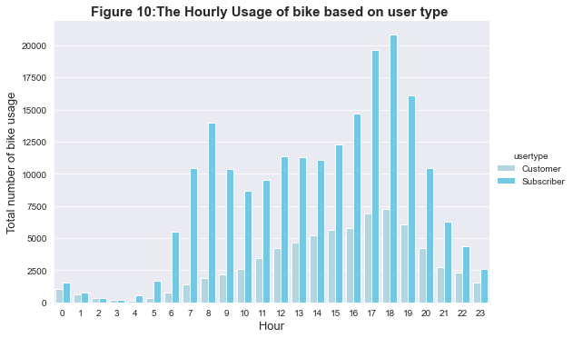

```python
plt.rcParams['font.family'] = "sans-serif"
plt.figure(figsize=(8,7))
sns.catplot(data = df1_clean, x='start_hour',hue='usertype' ,kind='count',palette=['#ADD8E6','#63D1F4'],aspect= 1.5);
plt.title("Figure 10:The Hourly Usage of bike based on user type ",fontsize=15, fontweight='bold')
plt.xlabel("Hour",fontsize=13)
plt.ylabel("Total number of bike usage",fontsize=13)
```

Subscriber user peaks out at 6pm. Another small peaks which was at 8am during morning rush hour. Customers ride behavior pattern does not correspond with subscribers as the trend increases untill 6pm and decreases after 6pm.

**Hourly Usage of bike based on user type during Weekdays**

```python
Weekday = df1_clean.query('start_day_week in ["Monday" , "Tuesday" , "Wednesday","Thursday","Friday"]' )
Weekend = df1_clean.query('start_day_week in ["Saturday" , "Sunday"]' )
```

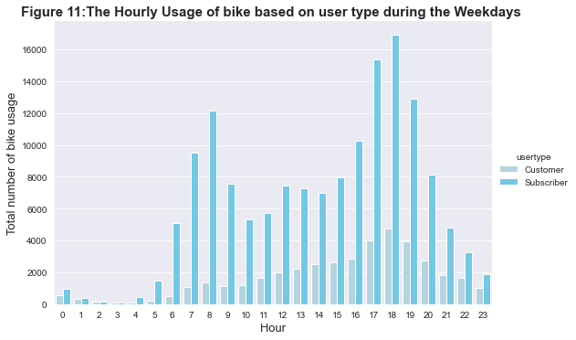

```python
plt.rcParams['font.family'] = "sans-serif"
plt.figure(figsize=(2,2))
sns.catplot(data = Weekday, x='start_hour',hue='usertype' ,kind='count',palette=['#ADD8E6','#63D1F4'],aspect= 1.5);
plt.title("Figure 11:The Hourly Usage of bike based on user type during the Weekdays ",fontsize=15, fontweight='bold')
plt.xlabel("Hour",fontsize=13)
plt.ylabel("Total number of bike usage",fontsize=13)
```

Based on the trend, we can assume that subscriber are most likely to use bike for work purpose

**Hourly Usage of bike based on user type during Weekend**

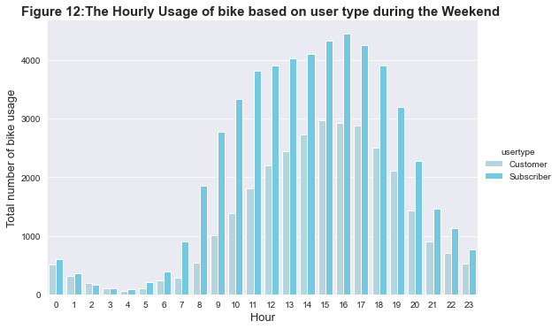

```python
plt.rcParams['font.family'] = "sans-serif"
plt.figure(figsize=(2,2))
sns.catplot(data = Weekend, x='start_hour',hue='usertype' ,kind='count',palette=['#ADD8E6','#63D1F4'],aspect= 1.5);
plt.title("Figure 12:The Hourly Usage of bike based on user type during the Weekend ",fontsize=15, fontweight='bold')
plt.xlabel("Hour",fontsize=13)
plt.ylabel("Total number of bike usage",fontsize=13)
```

The trend shows that most likely both subscribers and customer use the bike for leisure purpose

**Monthly Bike Usage based on user type**

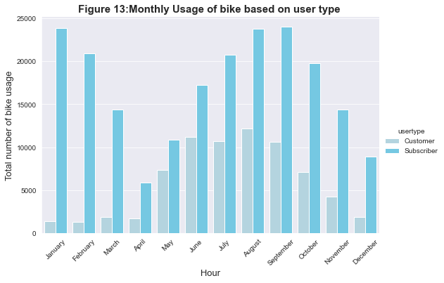

```python
plt.rcParams['font.family'] = "sans-serif"
plt.figure(figsize=(8,7))
sns.catplot(data = df1_clean, x='start_month',hue='usertype' ,kind='count',palette=['#ADD8E6','#63D1F4'],aspect= 1.5);
plt.title("Figure 13:Monthly Usage of bike based on user type ",fontsize=15, fontweight='bold')
plt.xlabel("Hour",fontsize=13)
plt.ylabel("Total number of bike usage",fontsize=13)
plt.xticks(rotation=45)
```

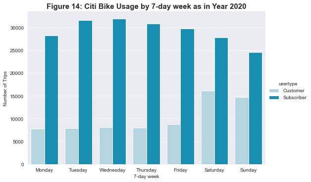

```python
plt.rcParams['font.family'] = "sans-serif"
label = ['Monday', 'Tuesday', 'Wednesday', 'Thursday', 'Friday', 'Saturday', 'Sunday']
sns.catplot(data=df1_clean, x='start_day_week', hue='usertype', kind='count',palette=['#ADD8E6','#009ACD'], order = label, aspect = 1.5)
plt.xlabel('7-day week')
plt.ylabel('Number of Trips')
plt.title('Figure 14: Citi Bike Usage by 7-day week as in Year 2020', fontsize=15, fontweight='bold');
```

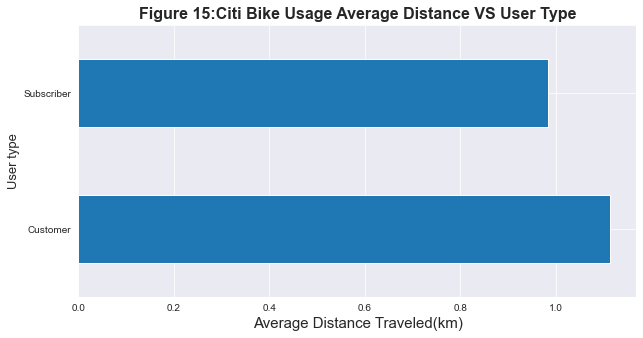

```python
df2 = df1_clean.groupby('usertype')['distance'].mean()
df2.plot(kind='barh',figsize=(10,5));

plt.title('Figure 15:Citi Bike Usage Average Distance VS User Type', fontsize=16, fontweight='bold')
plt.xlabel('Average Distance Traveled(km)',fontsize=15)
plt.ylabel('User type',fontsize=13)
```

Customer tend to have longer trips compared to subscriber

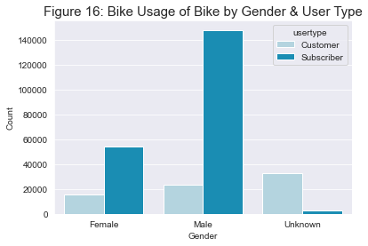

```python
sns.countplot(data=df1_clean, x='gender', hue='usertype', palette=['#ADD8E6','#009ACD'])

plt.ylabel('Count')
plt.xlabel('Gender')
plt.title("Figure 16: Bike Usage of Bike by Gender & User Type", fontsize=15);
```

Above Bar graph shows that subscriber rent the bike more than the customer. However it looks like from males are using the bike service more than females.

### Talk about some of the relationships you observed in this part of the investigation. How did the feature(s) of interest vary with other features in the dataset?

There are a lot of intersting things to analyze. Firstly, Figure 9 shows that the number of subscribers are way higher than the customers. Adding user type to our monthly, weekly , daily and hour analysis, I observed subscribers have a fixed schedule and prefer to rent bike on weekdays during rush hour 8am and 6pm after work. For customers, they are most likely to communute for leisure or entertainment purpose as the trend shows the increase of bike usage by time and decrease in the evening.

A lot of business got affected due to Covid 19 pandemic. Take a look at the bike trend as well. Acccording to BBC, as of April 2020 the government in New York City responsed to the Covid 19 pandemic with a full lockdown from March 2020 to April 2020, followed by a four-phase reopening plan by region from April 2020 to July 2020. We can observe that the bike usage significantly dropped on April and increase gradually after reopening phase which was on May.

### Did you observe any interesting relationships between the other features (not the main feature(s) of interest)?

Adding usertype , gender and average trip duration into the analysis, i observed that customers tend to travel longer than the subsribers. Most of the subscribers are male.

## Multivariate Exploration

> Create plots of three or more variables to investigate your data even further. Make sure that your investigations are justified, and follow from your work in the previous sections.

**How does the average trip duration vary in weekdays and weekend between customers and subscribers?**

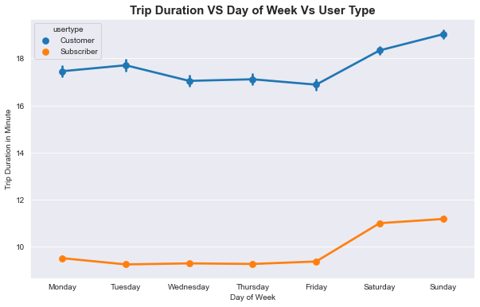

```python
plt.rcParams['font.family'] = "sans-serif"
plt.figure(figsize=(10,6))
order=['Monday', 'Tuesday', 'Wednesday', 'Thursday', 'Friday', 'Saturday', 'Sunday']
sns.pointplot(data=df1_clean, x='start_day_week', y='tripduration_min', hue='usertype',order=order);
plt.xlabel('Day of Week')
plt.ylabel('Trip Duration in Minute')
plt.title('Trip Duration VS Day of Week Vs User Type',fontsize=15,fontweight='bold')
```

It is clearly to see that subscribers tend to use bike for shorter trip compared to customer on each day of the week. Both user types shows similar trend on the weekend. Subscribers bike usage maintain a very consistence duration compare to customer.

**How does the hourly usage and day of week affect the bike ride behavior for both user types?**

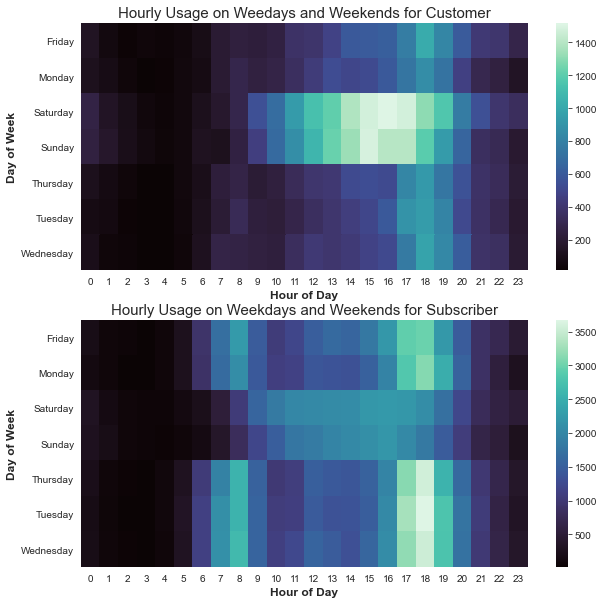

```python
plt.figure(figsize=(10,10))


plt.subplot(2, 1, 1)
customers = df1_clean.query('usertype == "Customer"')
customer_group = customers.groupby(['start_day_week', 'start_hour']).size()
customer_counts = customer_group.reset_index(name='count')
customer_counts = customer_counts.pivot(index='start_day_week', columns='start_hour', values='count')
sns.heatmap(customer_counts, cmap='mako')
plt.xlabel('Hour of Day',fontsize=12,fontweight='bold')
plt.ylabel('Day of Week',fontsize=12,fontweight='bold')
plt.title('Hourly Usage on Weedays and Weekends for Customer', loc='center',fontsize=15);

plt.subplot(2, 1, 2)
subscribers = df1_clean.query('usertype == "Subscriber"')
subscriber_group = subscribers.groupby(['start_day_week', 'start_hour'],sort=False).size()
subscriber_counts = subscriber_group.reset_index(name='count')
subscriber_counts = subscriber_counts.pivot(index='start_day_week', columns='start_hour', values='count')
sns.heatmap(subscriber_counts, cmap='mako')
plt.title('Hourly Usage on Weekdays and Weekends for Subscriber', loc='center',fontsize=15)
plt.xlabel('Hour of Day',fontsize=12, fontweight='bold')
plt.ylabel('Day of Week',fontsize=12, fontweight='bold')
plt.title('Hourly Usage on Weekdays and Weekends for Subscriber', loc='center',fontsize=15)
```

According to the Subscribers usage behavior pattern, they are mainly commute to work on the weekdays. However, customers tend to use more during the weekend.

### Talk about some of the relationships you observed in this part of the investigation. Were there features that strengthened each other in terms of looking at your feature(s) of interest?

Multivariate Exploration visually enhance the trip behavior between the two user types. Day of week, hour of day and user types are taken into the consideration for further analysis. According to the chart and heatmap, similar pattern can be seen and corresponding to each other.

### Were there any interesting or surprising interactions between features?

Customer trips are longer comparing to subscriber group. This is because they prefer bike rides over the weekends and which indicates they are possibly use for leisure and entertainment. According to the heatmap, subscribers has the similar pattern over the weekdays in which they prefer short distance communiting.

# **Summary**